# Univariate state-space models

4 Jan 2024

## Topics

Univariate state-space models

1. state (process) model
2. observation model

Simple models of population dynamics

## State-space models

Consist of 2 parts

## Part 1: State model

Describes the **true state of nature** over time

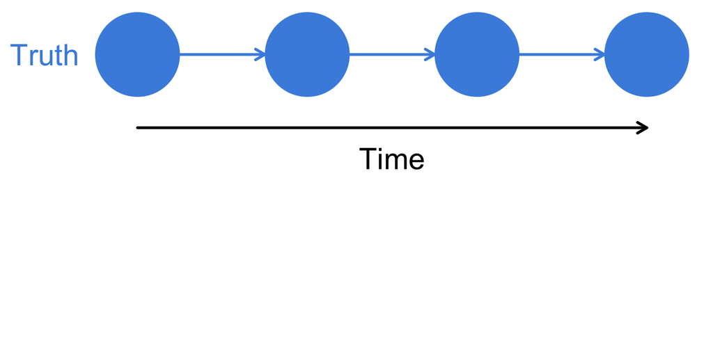

## Part 1: State model

States of nature might be:

- animal’s location
- density of organisms
- reproductive state

## Changes in the state of nature

We can think of changes in the state of nature being driven by a combination of

- intrinsic (eg, fecundity), and
- extrinsic factors (eg, temperature)

## Process errors

Some of the extrinsic drivers may be unknown

In time series modeling, we often call these unknown extrinsic factors *process errors*

## Observation (sampling) errors

Consider for a moment the very act of collecting data

Information gathered depends on many factors

- Environmental conditions (eg, cloud cover)
- Behavior (eg, threat avoidance)
- Demographics (age, sex, maturity)
- Sampling design/coverage
- Observer skill

## Part 2: Observation model

**Data = Truth + Error**

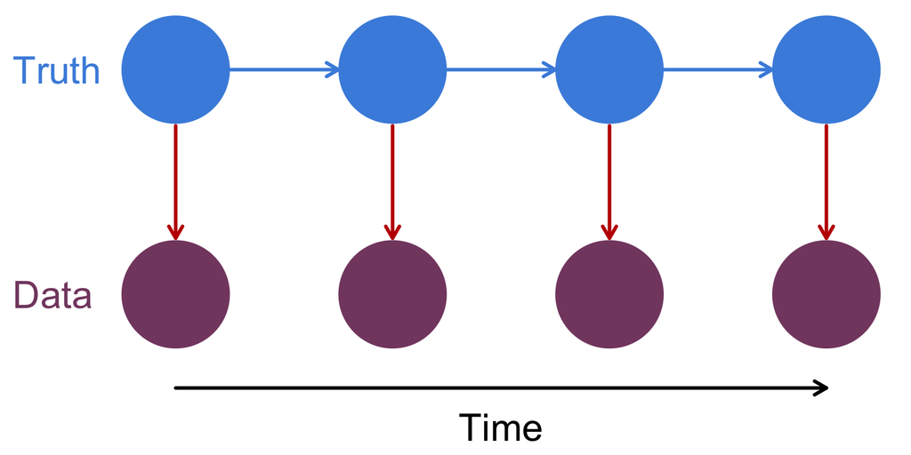

## State-space model

### General form

State model (autoregressive)

\(x_t = f(x_{t-1}, \text{process error})\)

Observation model

\(y_t = g(x_t, \text{observation error})\)

## State-space model

### Random walk

State model

\(x_t = x_{t-1} + w_t\) with \(w_t \sim \text{N}(0,q)\)

Observation model

\(y_t = x_t + v_t\) with \(v_t \sim \text{N}(0,r)\)

## State-space model

### Biased random walk

State model

\(x_t = x_{t-1} + u + w_t\) with \(w_t \sim \text{N}(0,q)\)

Observation model

\(y_t = x_t + v_t\) with \(v_t \sim \text{N}(0,r)\)

## State-space model

### Mean-reverting with \(|b| < 1\)

State model

\(x_t = b x_{t-1} + w_t\) with \(w_t \sim \text{N}(0,q)\)

Observation model

\(y_t = x_t + v_t\) with \(v_t \sim \text{N}(0,r)\)

## Consider these data

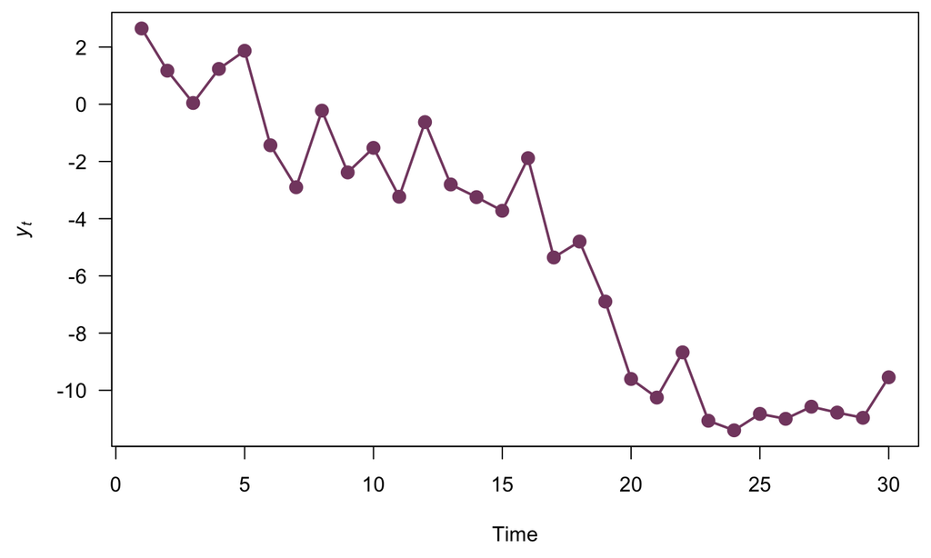

## Two model options

Linear regression

\(y_t = \alpha + \beta t + e_t\)

Biased random walk

\(x_t = x_{t-1} + u + e_t\)

## Model options

### Linear regression

State model

\(x_t = \alpha + \beta t\)

Observation model

\(y_t = x_t + v_t\) with \(v_t \sim \text{N}(0,r)\)

## Linear regression fitted values

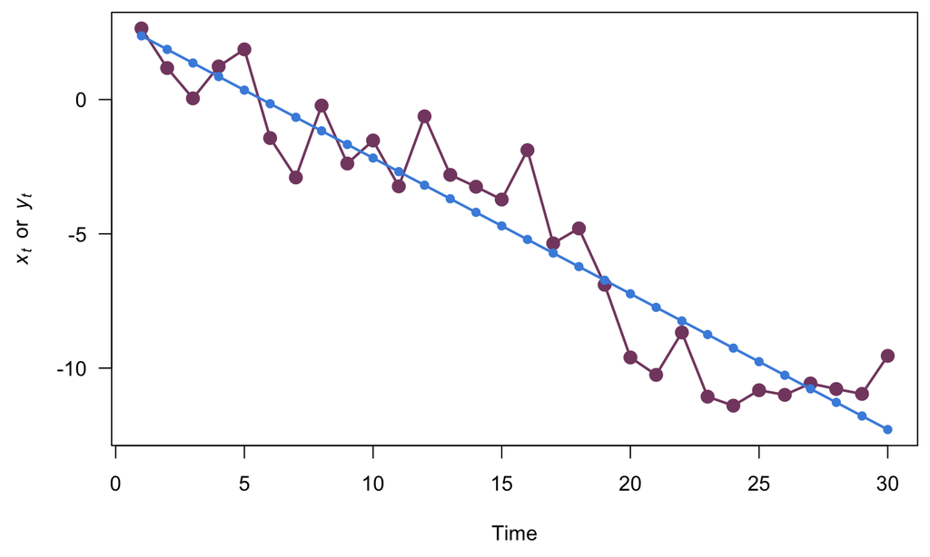

## Observation errors

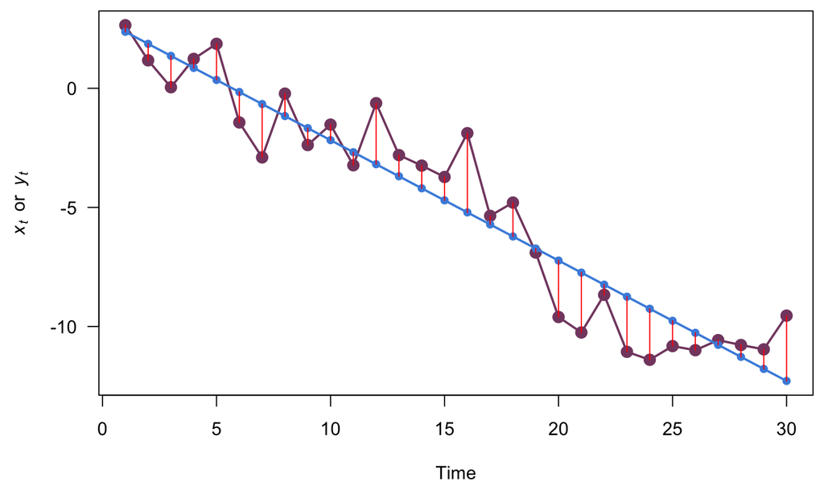

## Model options

### Biased random walk

State model

\(x_t = x_{t-1} + u + w_t\) with \(w_t \sim \text{N}(0,q)\)

Observation model

\(y_t = x_t\)

## Examples of biased random walks

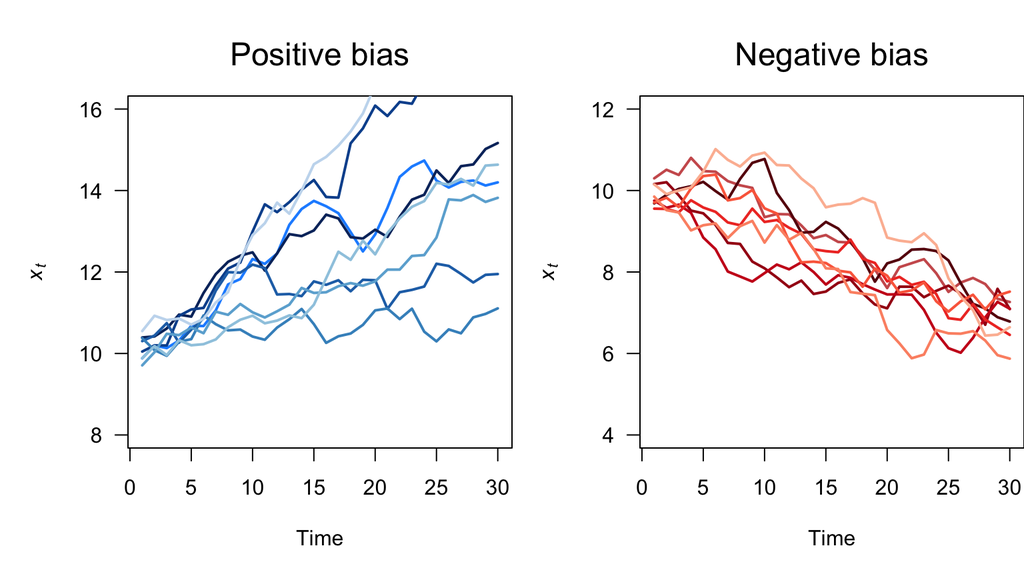

## Biased random walk

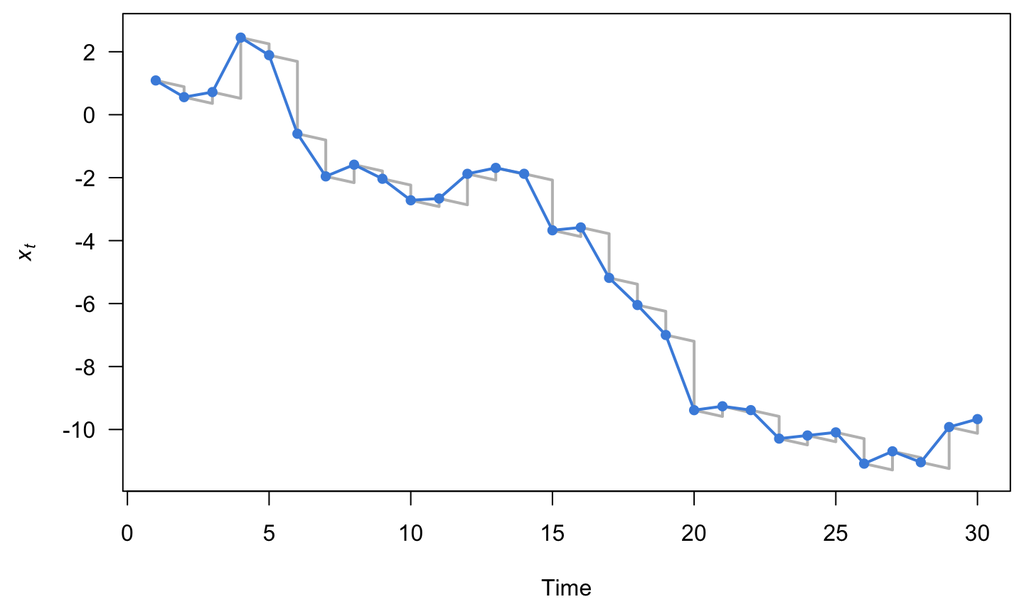

## Biased random walk fit to earlier data

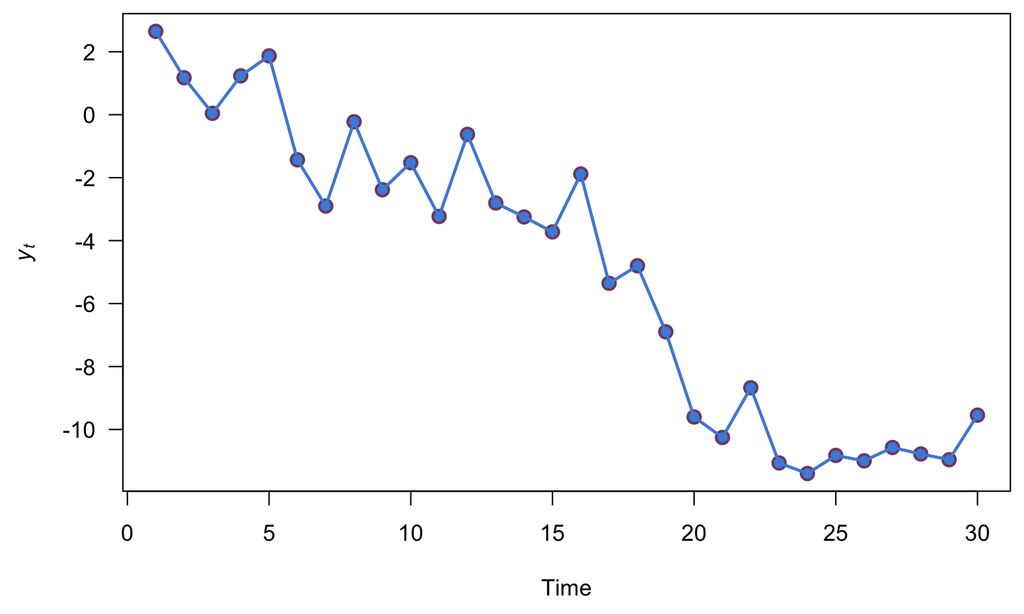

## Process errors

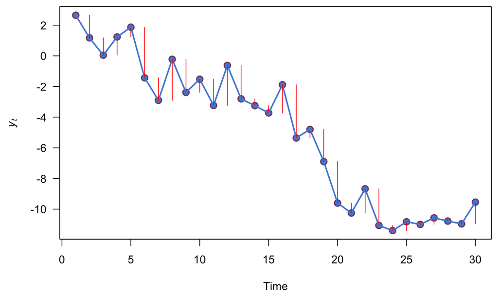

## Model options

### Biased random walk with observation error

State model

\(x_t = x_{t-1} + u + w_t\) with \(w_t \sim \text{N}(0,q)\)

Observation model

\(y_t = x_t + v_t\) with \(v_t \sim \text{N}(0,r)\)

## Biased random walk

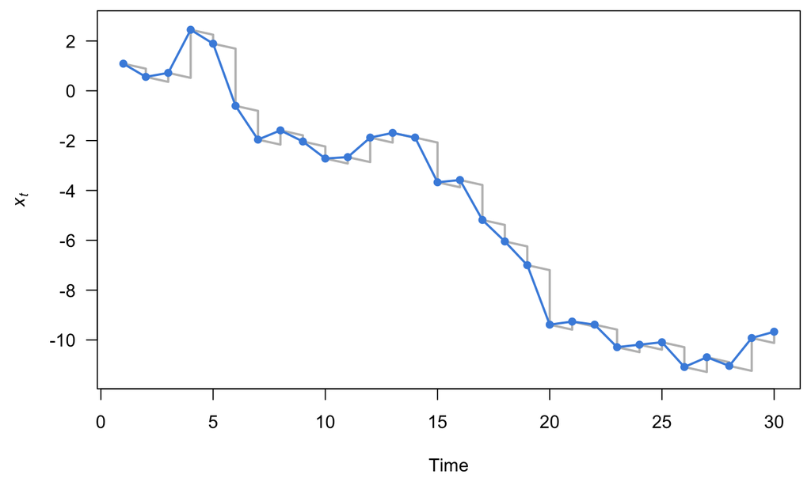

## Biased random walk

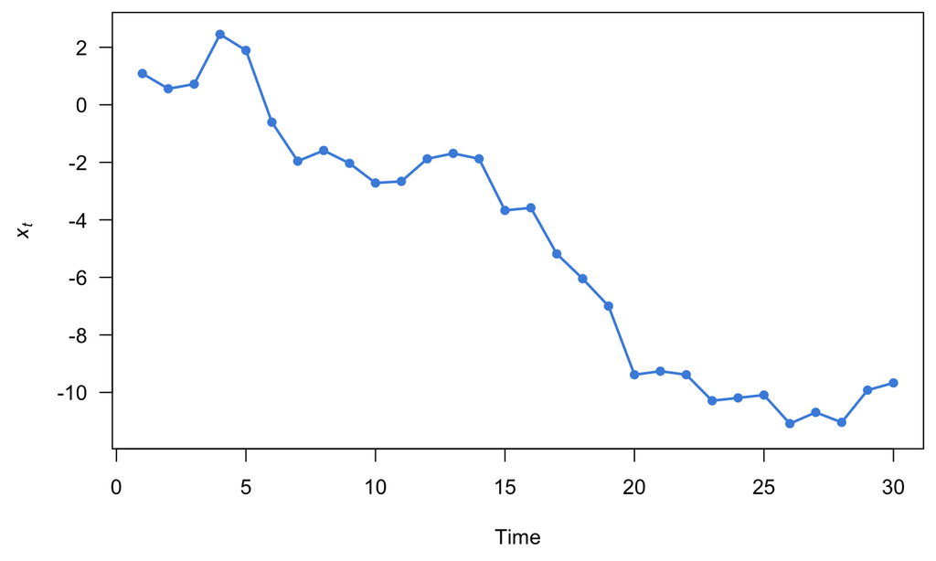

## Biased random walk with obs error

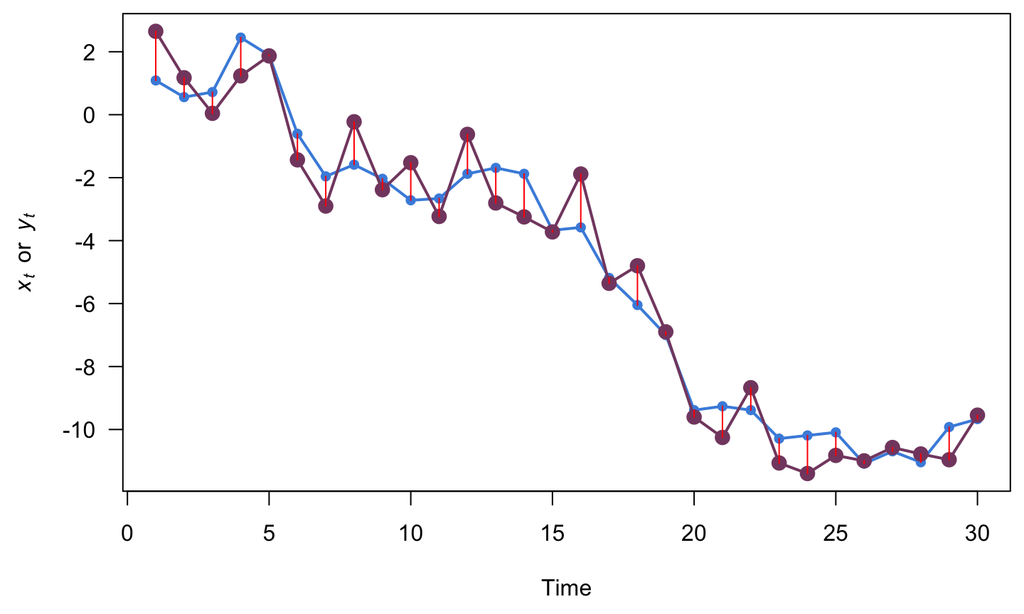

## Biased random walk with obs error

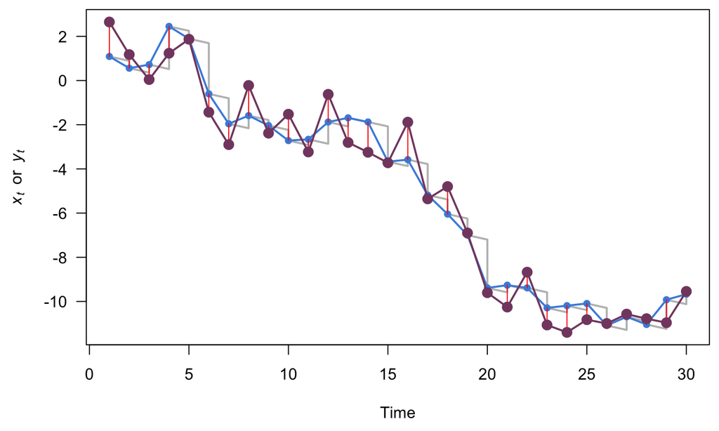

The variance in \(y_t\) is due to both process & observation error

## Separating process & obs errors

How is it possible to separate out both the process and observation errors?

They have different temporal patterns

## Separating process & obs errors

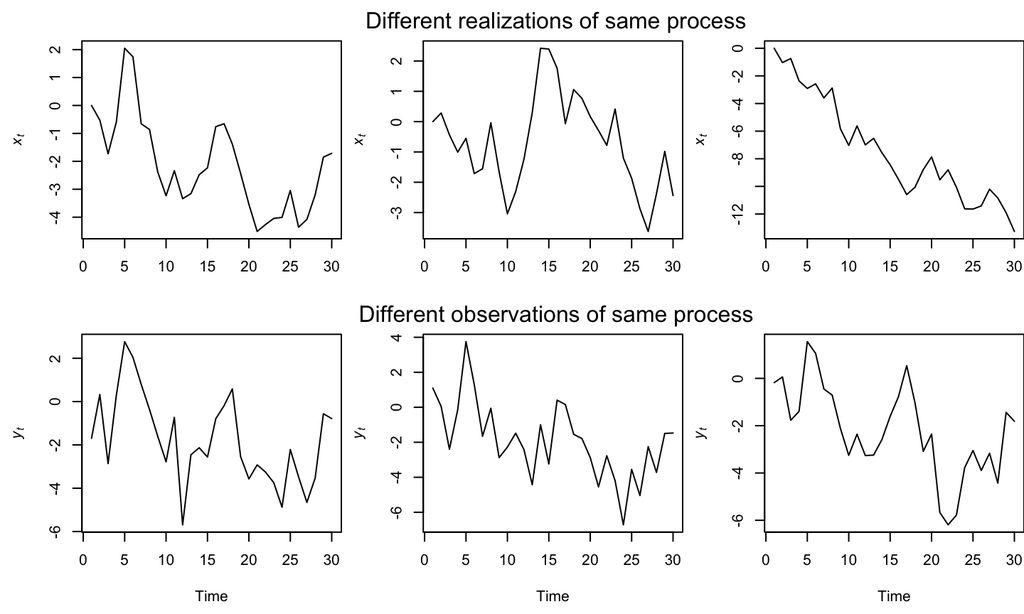

## Population growth

### Density independent

## Density-independent popn growth

### Exponential growth/decline in continuous time

\[ N(t) = N_0 ~ \underbrace{\exp(u)}_{\substack{\text{rate of} \\ \text{change}}} \underbrace{\exp(w t)}_{\substack{\text{stochastic} \\ \text{environment}}} \]

## Density-independent popn growth

### In discrete time, with a time step of 1 year

\[ N_t = N_{t-1} \exp(u + w_t) \]

## Density-independent popn growth

### In discrete time, with a time step of 1 year

\[ N_t = N_{t-1} \exp(u + w_t) \]

Taking the log of both sides and substituting \(x_t\) for \(\log(N_t)\)

\[ \log (N_t) = \log (N_{t-1}) + u + w_t \\ \Downarrow \\ x_t = x_{t-1} + u + w_t \]

## Density-independent popn growth

### Biased random walk

If we assume that the errors are white noise

\[ w_t \sim \text{N}(0, q) \]

then our model of populations dynamics

\[ x_t = x_{t-1} + u + w_t \]

is a biased random walk

## Simulate a biased random walk

```r
## number of time steps
TT <- 40
## bias term
uu <- 0.2
## time series of process errors with var = 1
ww <- rnorm(TT, 0, sqrt(1))
## initialize state & set x0 = w0
xx <- ww
## loop over time steps
for(t in 2:TT) {
  xx[t] <- uu + xx[t-1] + ww[t]
}
```

## Simulate a biased random walk

Add some observation error

```r
## obs errors with var = 0.3
vv <- rnorm(TT, 0, sqrt(0.3))
## obs data
yy <- xx + vv
```

## Log-population size over time

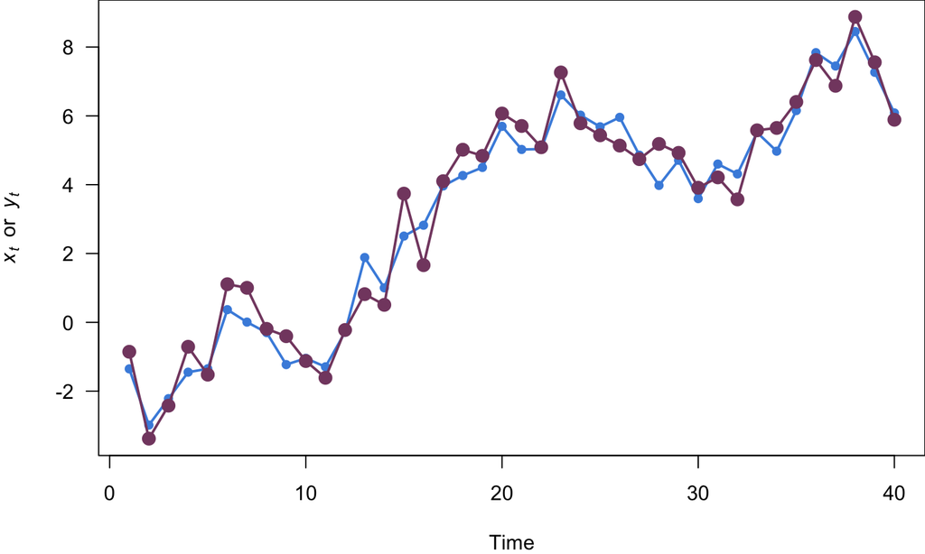